# Processing Structure Results

March 30 2016

### Background

As we’ve seen, in order to interpret structure runs, we need to work with multiple runs at a given k. STRUCTURE itself can readily visualize single runs, Structure Harvester is an easy online way to identify what value of K is worth examining, but what we would like to do is, having identified a K of interest, combine and visualize multiple runs. There is a commonly used pipeline for doing so, involving the use of two command-line programs

1. [CLUMPP] creates combined files
2. [distruct] produces graphical output

The problem is that both require some finesse in manually modifying parameter files, and many of those modifications are tricky. As an alternative, the workflow below allows you to achieve the same goal using the R package pophelper. It is available in github, so we have the usual initial installation steps:

```r
# library(devtools)
# install_github("royfrancis/pophelper")
library(pophelper)
```

More can be learned about this package [here](https://dl.dropboxusercontent.com/u/78814791/sites/pophelpervignette/vignette_v116.html)

### Data Preparation

What follows assumes that you have completed a STRUCTURE run, with multiple runs at each value of K over some range. You will need to locate the results folder for it and make a copy of it into your working directory. In the script that follows, results from analysis of data on Caribou in northern Canada have been placed in the file CaribouResults. The following code will create a vector of the file names and list them:

```r
flist <-list.files("./CaribouResults", full.names = TRUE)
flist
```

```
##  [1] "./CaribouResults/Default_run_1_f"
##  [2] "./CaribouResults/Default_run_10_f"
##  [3] "./CaribouResults/Default_run_11_f"
##  [4] "./CaribouResults/Default_run_12_f"
##  [5] "./CaribouResults/Default_run_13_f"
##  [6] "./CaribouResults/Default_run_14_f"
##  [7] "./CaribouResults/Default_run_15_f"
##  [8] "./CaribouResults/Default_run_16_f"
##  [9] "./CaribouResults/Default_run_17_f"
## [10] "./CaribouResults/Default_run_18_f"
## [11] "./CaribouResults/Default_run_19_f"
## [12] "./CaribouResults/Default_run_2_f"
## [13] "./CaribouResults/Default_run_20_f"
## [14] "./CaribouResults/Default_run_21_f"
## [15] "./CaribouResults/Default_run_22_f"
## [16] "./CaribouResults/Default_run_23_f"
## [17] "./CaribouResults/Default_run_24_f"
## [18] "./CaribouResults/Default_run_25_f"
## [19] "./CaribouResults/Default_run_3_f"
## [20] "./CaribouResults/Default_run_4_f"
## [21] "./CaribouResults/Default_run_5_f"
## [22] "./CaribouResults/Default_run_6_f"
## [23] "./CaribouResults/Default_run_7_f"
## [24] "./CaribouResults/Default_run_8_f"
## [25] "./CaribouResults/Default_run_9_f"
```

Having done that, we need to summarise the data. That requires two steps:

```r
df <-tabulateRunsStructure(files=flist) # Creates a data frame summarizing each individual runs
```

```
## Number of files selected: 25
```

```r
df2 <-summariseRunsStructure(df) # Creates a summary for each value of K
```

### The Evanno method

We can execute the Structure Harvester algorithm quite readily within R, and we can create either a simple plot or have our package generate a more elegant .png file. To just get the deltaK vs K plot, we can do the following:

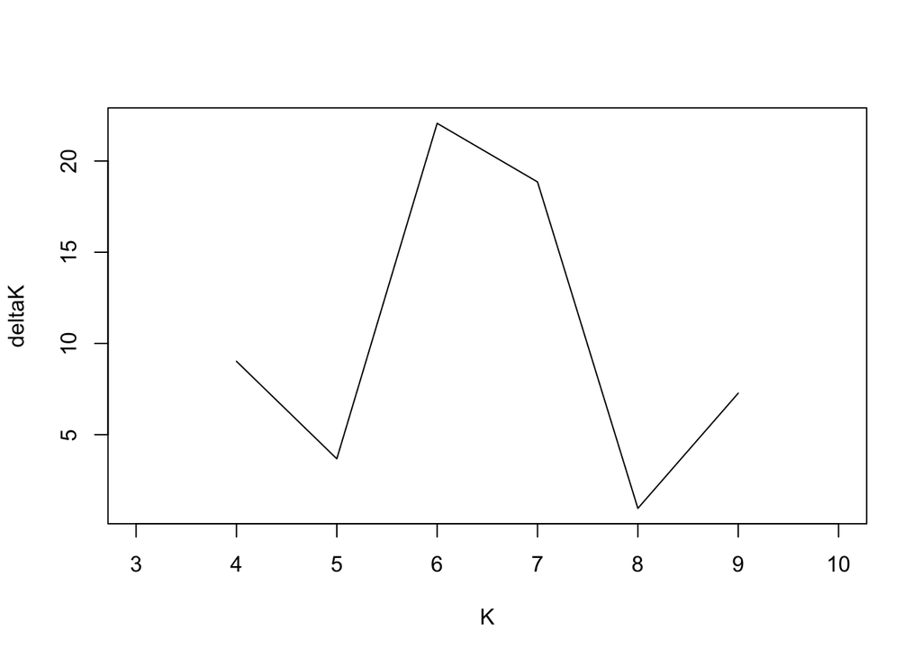

```r
df.ev <-evannoMethodStructure(df2)
plot(df.ev$k,df.ev$deltaK,xlab="K",ylab="deltaK",type="l")
```

Or, to generate a more elaborate file, we can run the same code as

```r
df.ev <-evannoMethodStructure(df2,exportplot = TRUE)
```

```
## evannoMethodStructure.png exported
```

this has now created a file called evannoMethodStructure.png, which can be opened with any graphical program, and looks like the following

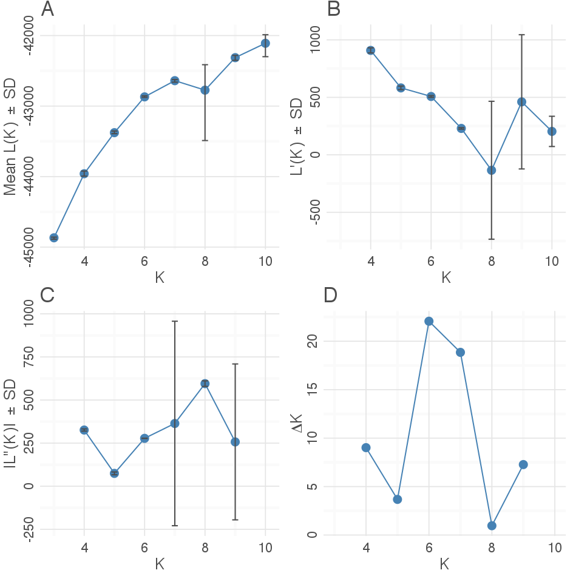

### Combining Runs with CLUMPP

There are actually a couple of problems with raw STRUCTURE output. First, in each run, the ordering of clusters (1 through K) is arbitrary, so that even though different runs may cluster samples identically (or nearly so), the numbering in each run is not the same (for example, cluster 1 in run 1 might be cluster 4 in run 2). Second, for display purposes, assuming that the runs have proven to be similar, we’d like to merge them into a single plot. CLUMPP will do both of those things.

#### 1. Produdcing CLUMPP input files.

CLUMPP requires two input files, one containing the combined results for a particular K and one with parameters for running the program. We can create these for each of our K values quite readily with the following

```r
clumppExportStructure(files=(flist),prefix="Caribou")
```

What this has done is to create a folder for each K value. we can see them as follows:

```r
list.files()
```

```
##  [1] "Caribou_K10"                     "Caribou_K3"
##  [3] "Caribou_K4"                      "Caribou_K5"
##  [5] "Caribou_K6"                      "Caribou_K6-combined-aligned.png"
##  [7] "Caribou_K6-combined-merged.png"  "Caribou_K6-combined.png"
##  [9] "Caribou_K7"                      "Caribou_K8"
## [11] "Caribou_K9"                      "CaribouPops.txt"
## [13] "CaribouResults"                  "Chapter.css"
## [15] "CLUMPP"                          "Default_run_10_f.png"
## [17] "evannoMethodStructure.png"       "html"
## [19] "indfile"                         "paramfile"
## [21] "permutationfile"                 "structure"
## [23] "Structure2016.Rproj"             "StructureProcess_files"
## [25] "StructureProcess.Rmd"
```

There happen to be a few other files in this folder, but note the ones of the format “Caribou_Kn”. Since our Evanno analysis suggested we look at K=6, let’s see what’s in that folder

```r
list.files("./Caribou_K6")
```

```
## [1] "Caribou_K6-combined.txt" "paramfile"
```

In fact, those are the two files we need to run CLUMPP.

#### 2. Running CLUMPP

To run CLUMPP, we need to have the CLUMPP executable file in the same directory as our two input files (those in Caribou_K6) We’ll do this in R, but if you prefer, you can do so just by moving and double clicking. First the R version:

```r
file.copy("CLUMPP","./Caribou_K6/CLUMPP") # Make a copy of CLUMPP in the K6 file
```

```
## [1] TRUE
```

```r
setwd("./Caribou_K6") # Move our R processing to that directory
system("./CLUMPP") # Run CLUMPP
list.files() # display the files in the folder # List the files
```

```
## [1] "Caribou_K6-combined-aligned.txt"  "Caribou_K6-combined-merged.txt"
## [3] "Caribou_K6-combined-miscfile.txt" "Caribou_K6-combined.txt"
## [5] "CLUMPP"                           "paramfile"
```

```r
setwd("..")
```

We now see a bunch of new stuff in the folder, much of which we can ignore. However, we will use one of those files to visualize the results.

As an alternative (on a Mac), you can do the following.

1. Open Finder
2. Navigate to the folder that contains the CLUMPP executable
3. Copy the executable into the folder with the input files (Caribou_K6 in the example)
4. With that folder open in Finder, double click on CLUMPP. You should see the additional files appear

#### 3. Visualizing the results.

This can be done with the program distruct, but as noted earlier, setting that up is a bit tricky. Fortunately for us, pophelper can do that fairly easily. First, let’s look at our three runs as they were produced by STRUCTURE

```r
plotRuns("./Caribou_K6/Caribou_K6-combined.txt",imgoutput = "tab")
```

```
## Caribou_K6-combined.png exported
```

The .png file produced shows the problem - the clusters are clearly the same, but the coloring (indicating cluster number) differs between runs.

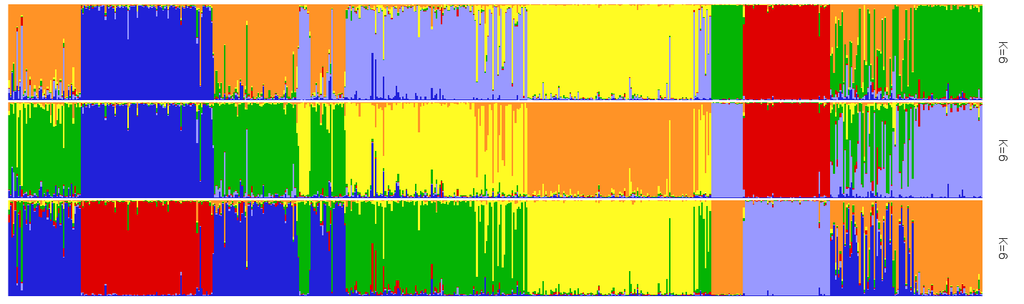

If we look at the CLUMPP output, we see that this problem is eliminated

```
## Caribou_K6-combined-aligned.png exported
```

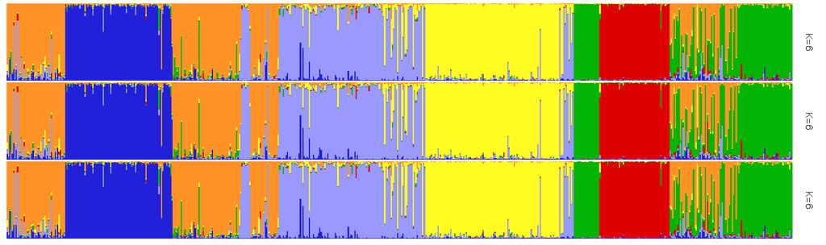

```r
plotRuns("./Caribou_K6/Caribou_K6-combined-aligned.txt",imgoutput = "tab")
```

Since these are clearly consistent, we can merge them:

```r
plotRuns("./Caribou_K6/Caribou_K6-combined-merged.txt",imgoutput = "tab")
```

```
## Caribou_K6-combined-merged.png exported
```

And again, a .png file is created.

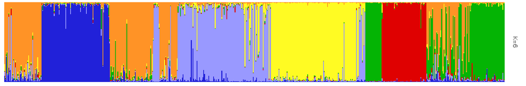

Note that at present, this is just a basic command; in fact the plotRuns function has a lot of options for labelling everything. Stay tuned for more.